# Reproduceable Research - Storm Data Analysis

Linton Galloway

25 October 2015

## Title

A very brief exploration of the publically available NOAA Storm Database.

## Synopsis

The basic goal of this assignment is to explore the publically available NOAA Storm Database and answer some basic questions about severe weather events. The assignment attempts to find the most harmful weather events in terms of economic and health consequences.In particular the questions are:

1. Across the United States, which types of events (as indicated in the EVTYPE variable) are most harmful with respect to population health?
2. Across the United States, which types of events have the greatest economic consequences?

## Data Processing

The approach taken to process the data is to:

1. rationalise duplicate weather events using a lookup chart available at https://github.com/lintong/RepData_StormAnalysis/blob/master/storm_lookup.csv and reduce the amount of significant duplication,
2. generate the sum of each type of weather event, using a desciminator of EVTYPE
3. select the top siginificant weather events using the event type’s quantile rank

```r
knitr::opts_chunk$set(cache=TRUE, warning=FALSE, message=FALSE)

inline_hook <- function(x){
  if(is.numeric(x)){
    paste(format(x,digits=2))
  }
}

knitr::knit_hooks$set(inline=inline_hook)

library(dplyr, warn.conflicts=FALSE)
library(reshape2)
library(ggplot2)
```

```r
url            <- 'https://d396qusza40orc.cloudfront.net/repdata%2Fdata%2FStormData.csv.bz2'
tempf          <- tempfile()
download.file(url, tempf, method="curl")
df             <- read.csv(bzfile(tempf))
```

```r
lookup_df      <- read.csv('storm_lookup.csv', colClasses = c("character","character"))
df             <- df %>% mutate_each(funs(tolower), EVTYPE)
df$EVTYPE_NEW  <- lookup_df[match(df$EVTYPE, lookup_df$OLD), 'NEW']
df             <- transform(df, EVTYPE = ifelse(is.na(EVTYPE_NEW), EVTYPE, EVTYPE_NEW))
```

```r
physical_by_evtype <- aggregate(cbind(FATALITIES, INJURIES)~EVTYPE, data=df, sum)
physical_quantiles <- sapply(physical_by_evtype[-1], quantile, probs = .97)
physical_by_evtype <- filter(physical_by_evtype,
                             FATALITIES >= physical_quantiles[1] |
                             INJURIES >= physical_quantiles[2])

economic_by_evtype <- aggregate(cbind(PROPDMG, CROPDMG)~EVTYPE, data=df, sum)
economic_quantiles <- sapply(economic_by_evtype[-1], quantile, probs = .97)
economic_by_evtype <- filter(economic_by_evtype,
                             PROPDMG >= economic_quantiles[1] |
                            CROPDMG >= economic_quantiles[2])

names(physical_by_evtype) <- c("EVTYPE", "fatalities", "injuries")
names(economic_by_evtype) <- c("EVTYPE", "property damage", "crop damage")

physical_by_evtype <- melt(physical_by_evtype, id.var="EVTYPE")
economic_by_evtype <- melt(economic_by_evtype, id.var="EVTYPE")
```

## Results

The result seem to indicate that tornados and flooding are collectively responsible for the greatest economic and health consequences.

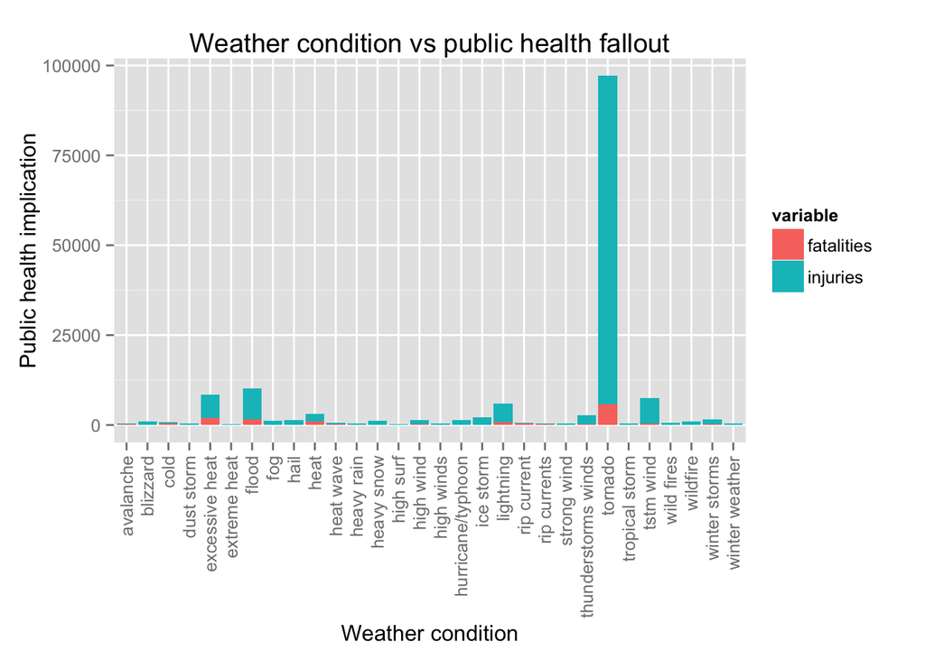

```r
# Publish the health fallout
ggplot(physical_by_evtype, aes(x = EVTYPE, y = value, fill = variable)) +
  geom_bar(stat = "identity") +
  theme(axis.text.x=element_text(angle=90,hjust=1,vjust=0.5)) +
  xlab("Weather condition") +
  ylab("Public health implication") +
  ggtitle("Weather condition vs public health fallout")
```

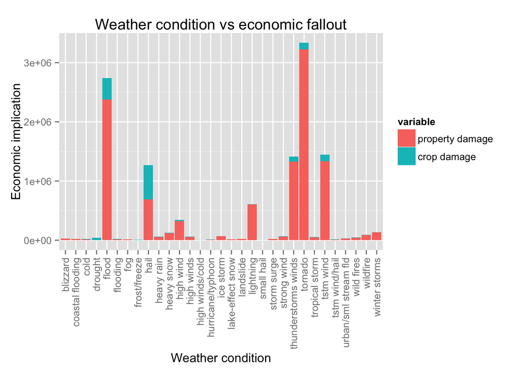

```r
# Publish the economic fallout
ggplot(economic_by_evtype, aes(x = EVTYPE, y = value, fill = variable)) +
  geom_bar(stat = "identity") +
  theme(axis.text.x=element_text(angle=90,hjust=1,vjust=0.5)) +
  xlab("Weather condition") +
  ylab("Economic implication") +
  ggtitle("Weather condition vs economic fallout")
```